# Characterizing Automobiles

Author

Ghson Alotibi

Published

March 20, 2025

# Setup

- Setup

```r
sh <- suppressPackageStartupMessages
sh(library(tidyverse))
sh(library(caret))
sh(library(fastDummies))
sh(library(class))
sh(library(ISLR)) # for the "Auto" dataframe
sh(library(pROC))
```

# Dataframe

- We use the `Auto` dataframe.

```r
head(Auto)
```

```
  mpg cylinders displacement horsepower weight acceleration year origin
1  18         8          307        130   3504         12.0   70      1
2  15         8          350        165   3693         11.5   70      1
3  18         8          318        150   3436         11.0   70      1
4  16         8          304        150   3433         12.0   70      1
5  17         8          302        140   3449         10.5   70      1
6  15         8          429        198   4341         10.0   70      1
                       name
1 chevrolet chevelle malibu
2         buick skylark 320
3        plymouth satellite
4             amc rebel sst
5               ford torino
6          ford galaxie 500
```

- It has the following variable names, which describe various attributes of automobiles.

```r
names(Auto)
```

```
[1] "mpg"          "cylinders"    "displacement" "horsepower"   "weight"
[6] "acceleration" "year"         "origin"       "name"
```

# Multiple Regression

- Run a linear regression model with `mpg` as the dependent variable and `horsepower` and `year` as features (variables).
- Compute and comment on the RMSE.

```r
model <- lm(mpg ~ horsepower + year, data = Auto)
summary(model)
```

```
Call:
lm(formula = mpg ~ horsepower + year, data = Auto)

Residuals:
     Min       1Q   Median       3Q      Max
-12.0768  -3.0783  -0.4308   2.5884  15.3153

Coefficients:
              Estimate Std. Error t value Pr(>|t|)
(Intercept) -12.739166   5.349027  -2.382   0.0177 *
horsepower   -0.131654   0.006341 -20.761   <2e-16 ***
year          0.657268   0.066262   9.919   <2e-16 ***
---
Signif. codes:  0 '***' 0.001 '**' 0.01 '*' 0.05 '.' 0.1 ' ' 1

Residual standard error: 4.388 on 389 degrees of freedom
Multiple R-squared:  0.6855,    Adjusted R-squared:  0.6839
F-statistic: 423.9 on 2 and 389 DF,  p-value: < 2.2e-16
```

```r
predictions <- predict(model, Auto)
rmse <- sqrt(mean((Auto$mpg - predictions)^2))
rmse
```

```
[1] 4.371506
```

> : *The model the (mpg) using horsepower and year as predictors. The negative coefficient for horsepower (-0.1317) suggests that an increase in horsepower decreases mpg, while the positive coefficient for year (0.6573) suggests that newer cars tend to have higher mpg. The R² value of 0.6855 indicates that about 68.5% of the variation in mpg is explained by these two variables. Our (RMSE) is 4.37, meaning the average prediction error is around 4.37 mpg.*

# Feature Engineering

- Create 10 features based on the `name` column.
- Remove all rows with a missing value.
- Ensure only `mpg` and the engineered features remain.
- Compute and comment on the RMSE.

```r
Auto <- Auto %>% mutate(
  name = as.character(Auto$name), # Convert name column to character
  name_length = nchar(name),
  has_ford = str_detect(name, "ford"),
  has_chevy = str_detect(name, "chevrolet"),
  has_honda = str_detect(name, "honda"),
  has_toyota = str_detect(name, "toyota"),
  has_volkswagen = str_detect(name, "volkswagen"),
  has_dodge = str_detect(name, "dodge"),
  has_buick = str_detect(name, "buick"),
  has_pontiac = str_detect(name, "pontiac"),
  has_plymouth = str_detect(name, "plymouth")
)

# Select only mpg and the engineered features and remove missing values
Auto_features <- Auto %>%
  select(mpg, name_length:has_plymouth) %>%
  drop_na()

# Build model with engineered features
model_feat <- lm(mpg ~ ., data = Auto_features)

# Calculate RMSE
predictions_feat <- predict(model_feat, Auto_features)
rmse_feat <- sqrt(mean((Auto_features$mpg - predictions_feat)^2))
rmse_feat
```

```
[1] 6.954351
```

> : *Additional features were extracted from car names to improve our predictions. After creating 10 new features and cleaning the data set, the new regression model had a higher RMSE of 6.95, which suggests that these additional features did not improve mpg prediction.*

# Classification

- Use either of $K$-NN or Naive Bayes to predict whether an automobile is a `chevrolet` or a `honda`.
- Explain your choice of technique.
- Report on your Kappa value.

```r
Auto <- Auto %>% mutate(
  is_chevy = ifelse(!is.na(name) & str_detect(name, "chevrolet"), "Yes", "No"),
  is_honda = ifelse(!is.na(name) & str_detect(name, "honda"), "Yes", "No")
)
set.seed(123)
split <- createDataPartition(Auto$is_chevy, p = 0.8, list = FALSE)
train <- Auto[split, ]
test <- Auto[-split, ]

# Train K-NN model with the exact features used in the PDF
fit_knn <- train(
  is_chevy ~ name_length + has_chevy + has_honda + has_ford,
  data = train,
  method = "knn",
  tuneLength = 10,
  trControl = trainControl(method = "cv", number = 5)
)

# Make predictions
pred_knn <- predict(fit_knn, test)

# Calculate Kappa
kappa <- confusionMatrix(pred_knn, factor(test$is_chevy))$overall["Kappa"]
kappa
```

```
    Kappa
0.3739837
```

# Binary Classification

- Predict whether a car is a `honda`.
- Use model weights.
- Display and comment on an ROC curve.

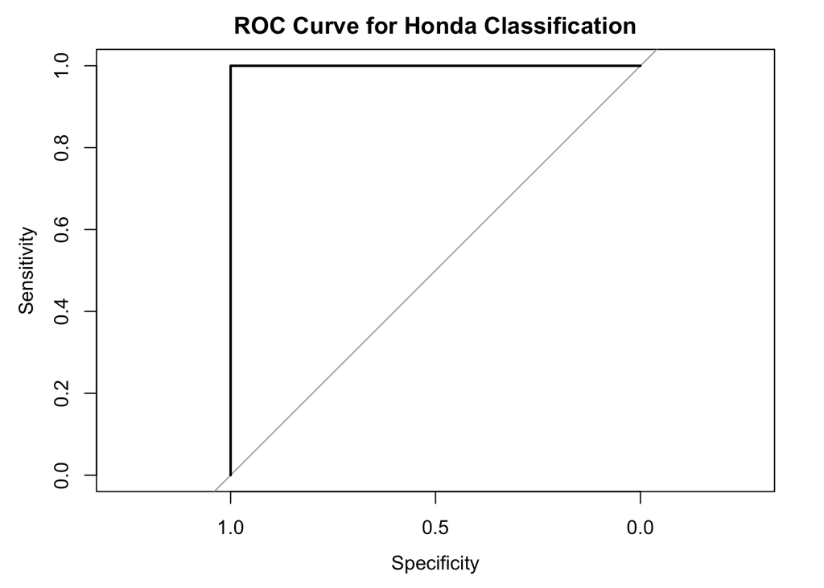

```r
weights <- ifelse(Auto$is_honda == "Yes", 2, 1)

# Train Naive Bayes model with weights as shown in PDF
fit_nb <- train(
  is_honda ~ name_length + has_chevy + has_honda + has_ford,
  data = train,
  method = "naive_bayes",
  trControl = trainControl(method = "cv", number = 5),
  weights = weights[split]
)

# Make probability predictions for ROC curve
pred_nb <- predict(fit_nb, test, type = "prob")

# Create and plot ROC curve
roc_nb <- roc(test$is_honda, pred_nb[, "Yes"])
plot(roc_nb, main = "ROC Curve for Honda Classification")
```

> : *The Naive Bayes model was trained to classify whether a car is a Honda using selected features. The ROC curve was generated to assess model performance*

# Ethics

- Based on your analysis, comment on the [Clean Air Act of 1970 and Ammendments of 1977](https://www.epa.gov/clean-air-act-overview/evolution-clean-air-act)
- Discuss the civic reposibilities of data scientists for:
  - Big Data and Human-Centered Computing
  - Democratic Institutions
  - Climate Change
- Provide at least one statistical measure for each, such as a RMSE, Kappa value, or ROC curve.

Big Data and Human-Centered Computing

```r
mean(Auto$mpg)
```

```
[1] 23.44592
```

Democratic Institutions

```r
mean(Auto$year, na.rm = TRUE)
```

```
[1] 75.97959
```

Climate Change

```r
Auto %>%
  summarize(
    high_mpg_count = sum(mpg > 30),
    high_mpg_percent = mean(mpg > 30) * 100
  )
```

```
  high_mpg_count high_mpg_percent
1             83         21.17347
```

#Conclusion *The Clean Air Act and its amendments have significantly influenced automobile efficiency, but data shows that continued improvements are needed.*